# Greedy heuristic sanity check

Anne Hartebrodt

October 8, 2018

# Data and parameters

The greedy heuristic has been performed using the known number of “forground” nodes as maximum network size. For data with more than one “forground” network the maximum network size has been set to a slightly higher number of nodes in order to allow the greedy heuristic to jump to the next network and find all good = forground nodes.

## Distribution of foreground and backgound p-values for all the datasets

```r
filelocation<-"/home/anne/Masterarbeit/pipeline_easy/result/biogrid//"
goldstandard<-"/home/anne/Masterarbeit/pipeline_easy/sample_data/biogrid//"

dd<-dir(goldstandard)
dat<-data.frame()
for(pdir in dd){
  files<-grep("general", dir(file.path(goldstandard, pdir)), value = T)
for(f in files){
df<-fread(file.path(goldstandard, pdir, f))
df$file<-f
df$dir<-pdir
dat<-rbind(dat,df)
}
}
g0<-ggplot(dat, aes(x=V2, fill=file))+geom_histogram(position = "dodge", bins = 100)+ggtitle("Distribution of p-values in dataset")+xlab("P-Value")+ylab("Count")+guides(fill=F)+facet_wrap("dir", nrow = 1)
```

## Overlap of gold standard gene set with detected (solution) networks

In order to assess wether the found solution was close enough to the foreground “gold standard” solution previously hidden in the network, the jaccard index was calculated. A Jaccard index of 1 means, that only the genes in the foreground gene set where contained in the solution.

Below, we see the distribution of the forground and background p-values, with variing degree of overlap and the corresponding performance of the greedy heuristic measured using the Jaccard index.

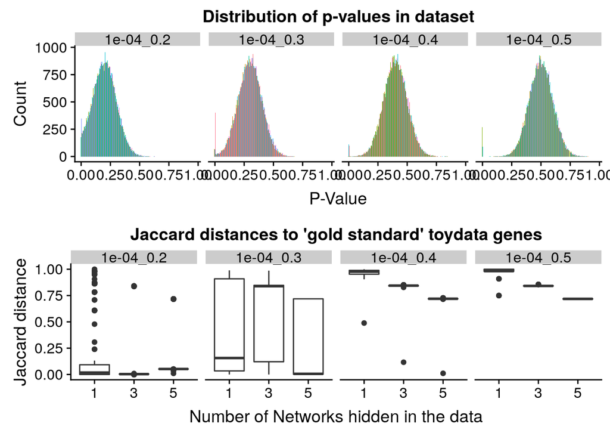

```r
network_jaccard$nr_networks<-as.factor(network_jaccard$nr_networks)
g1 <-ggplot(network_jaccard) + geom_boxplot(aes(x=nr_networks,y = jaccard_dists)) +
  ggtitle("Jaccard distances to 'gold standard' toydata genes") + ylab("Jaccard distance") +
  theme()+xlab("Number of Networks hidden in the data")+facet_wrap("run", nrow = 1)
plot_grid(g0, g1, ncol = 1)
```